# analysis

## Metaphor Analysis

We have several dependent variables which we would like to model as accurately as possible to determine the variables which contribute most to their outcomes. In particular, we care about the effect of the dominance (or lack thereof) of metaphor in each project. We first explore the data a little, and then begin a series of model comparisons for the dependent variables. Comparing models gives transparency to the contributions of each variable toward the target.

## Load Data

```r
dat = read.csv('../../data/processed/cancer_projects_full.csv')
head(dat)
```

```
##           id                                                        name
## 1  506225359 In Sickness and in Health- a couples journey through cancer
## 2 1762697805                Been There, Done That  - The Book.  The Life
## 3  974434688            Surviving the Journey: Letters from the Railroad
## 4 1665364667                                           A Recipe for Hope
## 5 2128470198                                 A Son's Breast Cancer Story
## 6  798429667          Grumpy Fish Aid…Comfort Tips From Kids with Cancer
##                                                                                                                                     blurb
## 1 A book about a couples first year of marriage. Read the inspirational story of how God helped them overcome cancer, amputation and more
## 2   Stage 4 cancer/addiction/homeless. Producing movies/concerts/ communing w/gurus/celebrities. Live "8 lives" to the max or die trying!
## 3                         A young cancer survivor embarks on a cross country railroad adventure while writing her memoir through letters.
## 4    Our family's journey living with and fighting incurable Stage 4 cancer and how we defeated it with family, friends, faith, and food.
## 5             A son who lost his mother to Breast cancer. Incredible battle that lasted 19 years. Support him in the writing of the book.
## 6    Illustrated acupressure, reflexology points; scratch & sniff aromatherapy…stretch goal: get books to newly diagnosed kids w/ cancer.
##      created   launched   deadline  goal spotlight staff_pick status
```

[output cut: 76 more lines]

```r
colnames(dat)
```

```
##  [1] "id"                    "name"
##  [3] "blurb"                 "created"
##  [5] "launched"              "deadline"
##  [7] "goal"                  "spotlight"
##  [9] "staff_pick"            "status"
## [11] "status_changed_at"     "backers"
## [13] "usd_pledged"           "pledged"
## [15] "currency"              "current_currency"
## [17] "fx_rate"               "category"
## [19] "geo_country"           "geo_state"
## [21] "geo_type"              "url"
## [23] "text"                  "mean_donation"
## [25] "text_length_words"     "text_length_sentences"
## [27] "pledged_to_goal"       "duration"
## [29] "duration_float"        "month"
## [31] "day_of_week"           "year"
## [33] "from_US"               "from_Town"
## [35] "blurb_length_words"    "battle_metaphor"
## [37] "journey_metaphor"      "battle_uniques"
## [39] "journey_uniques"       "battle_salience"
## [41] "journey_salience"      "battle_productivity"
## [43] "journey_productivity"  "dominant_battle"
## [45] "dominant_journey"      "dominant_both"
## [47] "dominant_neither"      "dominant"
```

```r
unique(dat$category)
```

```
##  [1] publishing    technology    fashion       crafts_games  film & video
##  [6] music         design_art    photography   dance_theater food
## [11] journalism
## 11 Levels: crafts_games dance_theater design_art fashion ... technology
```

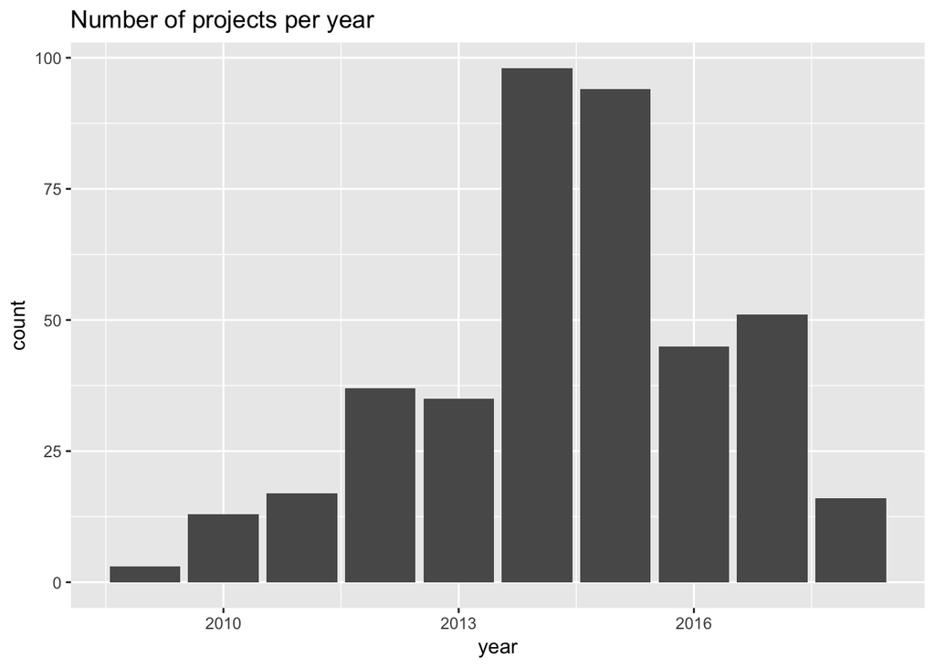

```r
library(ggplot2)
library(lme4)
ggplot(dat) + geom_bar(aes(x=year), stat="count") + ggtitle("Number of projects per year")
```

Very few projects are in 2009, and so for simplicity’s sake and to simplify the model just a tad, we remove 2009.

```r
dat <- dat[dat$year >= 2010, ]
```

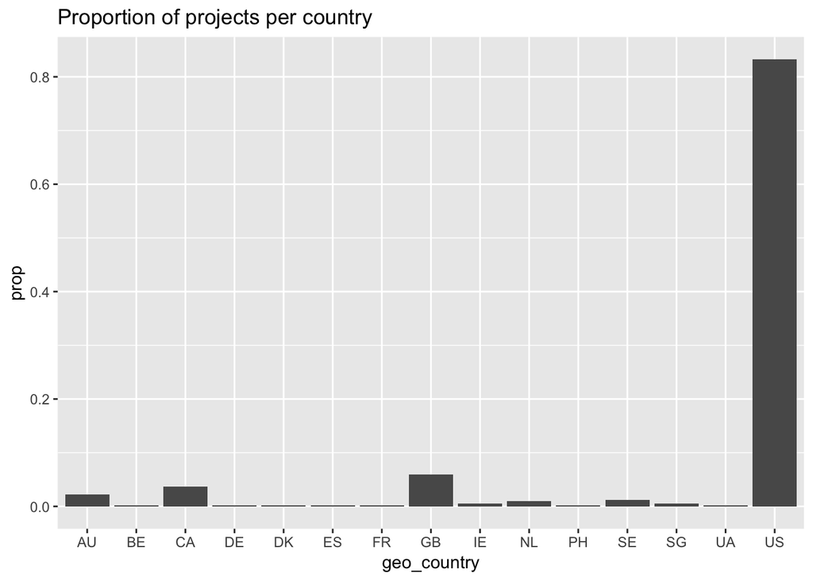

```r
ggplot(dat) + geom_bar(aes(x=geo_country, y=..prop.., group=1), stat="count") + ggtitle("Proportion of projects per country")
```

```r
dat <- dat[dat$geo_country == "US", ]
```

```r
nrow(dat[dat$from_Town == 0, ])
```

```
## [1] 10
```

```r
nrow(dat[dat$from_Town == 1, ])
```

```
## [1] 328
```

There are only 10 projects not from Towns, so we’ll just remove them for simplicity’s sake.

```r
dat <- dat[dat$from_Town == 1, ]
```

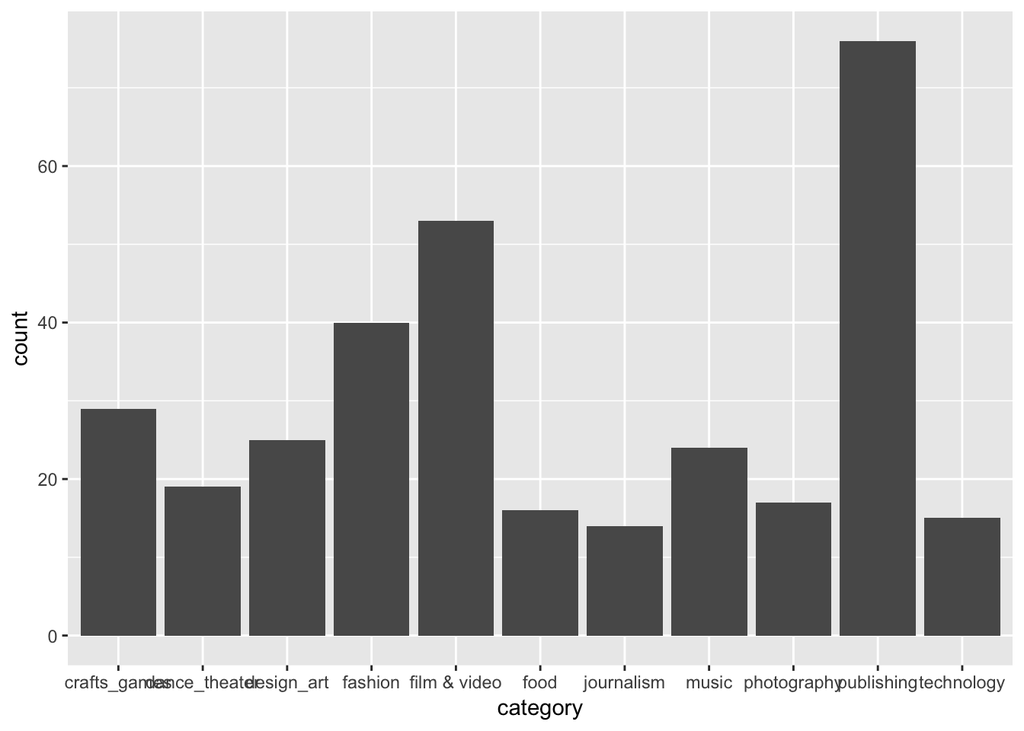

```r
ggplot(dat) + geom_bar(aes(x=category), stat="count")
```

We scale the data and convert binary values to floating point values.

```r
dat$goal_sc <- scale(dat$goal)
dat$duration_float_sc <- scale(dat$duration_float)
dat$text_length_words_sc <- scale(dat$text_length_words)
dat$staff_pick_sc <- scale(dat$staff_pick * 1)
dat$dominant_battle_sc <- scale(dat$dominant_battle * 1)
dat$dominant_journey_sc <- scale(dat$dominant_journey * 1)
dat$dominant_neither_sc <- scale(dat$dominant_neither * 1)
```

Seems like a comprehensive source: https://bbolker.github.io/mixedmodels-misc/glmmFAQ.html#model-definition https://ase.tufts.edu/gsc/gradresources/guidetomixedmodelsinr/mixed%20model%20guide.html

We are interested in the effect that metaphor dominance has on the funding status of a project.

Each sample is independent (what is in one project has no affect on whats in another sample).

DV: status, pledged_to_goal, mean_donation, backers IV: Goal amount, staff_pick, category, geo_state, from_town, text_length_words, duration_float, month, dow, year, dominant_*

Various sources were used to determine what should be a random effect and what should be fixed, and how to model interactions and correlations between variables, including:

- Data Analysis Using Regression and Multilevel/Hierarchical Models (Gelman and Hill, 2006)
- Interactions in Generalized Linear Models: Theoretical Issues and an Application to Personal Vote-Earning Attributes (Tsai and Gill, 2013)
- Should I Use Fixed or Random Effects? (Clark and Linzer, 2012)
- Random effects structure for confirmatory hypothesis testing: Keep it maximal (Barr et al., 2013)
- https://stats.stackexchange.com/questions/13166/rs-lmer-cheat-sheet
- https://stats.stackexchange.com/questions/4700/what-is-the-difference-between-fixed-effect-random-effect-and-mixed-effect-mode/151800#151800
- https://rlbarter.github.io/Practical-Statistics/2017/03/03/fixed-mixed-and-random-effects/
- https://stats.stackexchange.com/questions/323273/what-to-do-with-random-effects-correlation-that-equals-1-or-1
- Fitting linear mixed-effects models using lme4 (Bates et al., 2014)

# Status

```r
mod.none.corr <- glmer(status ~ month + (month|year) + (1|geo_state), data = dat, family = "binomial")
```

```
## singular fit
```

```r
as.data.frame(VarCorr(mod.none.corr))
```

```
##         grp        var1  var2         vcov        sdcor
## 1 geo_state (Intercept)  <NA> 6.088443e-15 7.802847e-08
## 2      year (Intercept)  <NA> 0.000000e+00 0.000000e+00
## 3      year       month  <NA> 1.275283e-02 1.129284e-01
## 4      year (Intercept) month 0.000000e+00          NaN
```

```r
# no fixed effects, only random
mod.none <- glmer(status ~ (1|geo_state) + month + (month|year), data = dat, family = "binomial", nAGQ = 1)
```

```
## singular fit
```

```r
# add staff pick
mod.staff <- glmer(status ~ staff_pick + (1|geo_state) + month + (month|year), data = dat, family = "binomial", nAGQ = 1)
```

```
## singular fit
```

```r
# add duration of campaign (in days)
mod.staff.dur <- glmer(status ~ duration_float_sc + staff_pick + (1|geo_state) + month + (month|year), data = dat, family = "binomial", nAGQ = 1)
```

```
## singular fit
```

```r
# add length of text (in words)
mod.staff.dur.length <- glmer(status ~ text_length_words_sc + duration_float_sc + staff_pick + (1|geo_state) + month + (month|year), data = dat, family = "binomial", nAGQ = 1)
```

```
## singular fit
```

```r
# add scaled goal amount
mod.staff.dur.length.goal <- glmer(status ~ goal_sc + text_length_words_sc + duration_float_sc + staff_pick + (1|geo_state) + month + (month|year), data = dat, family = "binomial", nAGQ = 1)
```

```
## singular fit
```

```r
anova(mod.none, mod.staff, test='Chisq')
```

```
## Data: dat
## Models:
## mod.none: status ~ (1 | geo_state) + month + (month | year)
## mod.staff: status ~ staff_pick + (1 | geo_state) + month + (month | year)
##           Df    AIC    BIC  logLik deviance  Chisq Chi Df Pr(>Chisq)
## mod.none   6 441.54 464.29 -214.77   429.54
## mod.staff  7 411.30 437.85 -198.65   397.30 32.239      1  1.363e-08 ***
## ---
## Signif. codes:  0 '***' 0.001 '**' 0.01 '*' 0.05 '.' 0.1 ' ' 1
```

```r
anova(mod.staff, mod.staff.dur, test='Chisq')
```

```
## Data: dat
## Models:
## mod.staff: status ~ staff_pick + (1 | geo_state) + month + (month | year)
## mod.staff.dur: status ~ duration_float_sc + staff_pick + (1 | geo_state) + month +
## mod.staff.dur:     (month | year)
##               Df    AIC    BIC  logLik deviance  Chisq Chi Df Pr(>Chisq)
## mod.staff      7 411.30 437.85 -198.65   397.30
## mod.staff.dur  8 412.85 443.19 -198.42   396.85 0.4502      1     0.5022
```

```r
anova(mod.staff.dur, mod.staff.dur.length, test='Chisq')
```

```
## Data: dat
## Models:
## mod.staff.dur: status ~ duration_float_sc + staff_pick + (1 | geo_state) + month +
## mod.staff.dur:     (month | year)
## mod.staff.dur.length: status ~ text_length_words_sc + duration_float_sc + staff_pick +
## mod.staff.dur.length:     (1 | geo_state) + month + (month | year)
##                      Df    AIC    BIC  logLik deviance Chisq Chi Df
## mod.staff.dur         8 412.85 443.19 -198.42   396.85
## mod.staff.dur.length  9 415.71 449.85 -198.85   397.71     0      1
##                      Pr(>Chisq)
## mod.staff.dur
## mod.staff.dur.length          1
```

```r
anova(mod.staff.dur.length, mod.staff.dur.length.goal, test='Chisq')
```

```
## Data: dat
## Models:
## mod.staff.dur.length: status ~ text_length_words_sc + duration_float_sc + staff_pick +
## mod.staff.dur.length:     (1 | geo_state) + month + (month | year)
## mod.staff.dur.length.goal: status ~ goal_sc + text_length_words_sc + duration_float_sc +
## mod.staff.dur.length.goal:     staff_pick + (1 | geo_state) + month + (month | year)
##                           Df    AIC    BIC  logLik deviance  Chisq Chi Df
## mod.staff.dur.length       9 415.71 449.85 -198.85   397.71
## mod.staff.dur.length.goal 10 380.05 417.98 -180.02   360.05 37.662      1
##                           Pr(>Chisq)
## mod.staff.dur.length
## mod.staff.dur.length.goal  8.413e-10 ***
## ---
## Signif. codes:  0 '***' 0.001 '**' 0.01 '*' 0.05 '.' 0.1 ' ' 1
```

```r
summary(mod.staff.dur.length.goal)
```

```
## Generalized linear mixed model fit by maximum likelihood (Laplace
##   Approximation) [glmerMod]
##  Family: binomial  ( logit )
## Formula: status ~ goal_sc + text_length_words_sc + duration_float_sc +
##     staff_pick + (1 | geo_state) + month + (month | year)
##    Data: dat
##
##      AIC      BIC   logLik deviance df.resid
##      380      418     -180      360      318
##
## Scaled residuals:
##     Min      1Q  Median      3Q     Max
## -2.2972 -0.7482  0.0000  0.7308  3.1844
##
## Random effects:
##  Groups    Name        Variance  Std.Dev.  Corr
##  geo_state (Intercept) 3.810e-10 1.952e-05
##  year      (Intercept) 7.981e-01 8.934e-01
##            month       6.368e-05 7.980e-03 -1.00
## Number of obs: 328, groups:  geo_state, 45; year, 9
##
## Fixed effects:
##                       Estimate Std. Error z value Pr(>|z|)
## (Intercept)           -0.17766    0.48208  -0.369 0.712476
## goal_sc               -4.18920    1.11133  -3.770 0.000164 ***
## text_length_words_sc   0.70656    0.17636   4.006 6.17e-05 ***
## duration_float_sc     -0.02155    0.13182  -0.164 0.870115
## staff_pickTrue        20.18214  295.60344   0.068 0.945567
## month                 -0.01853    0.04470  -0.415 0.678493
## ---
## Signif. codes:  0 '***' 0.001 '**' 0.01 '*' 0.05 '.' 0.1 ' ' 1
##
## Correlation of Fixed Effects:
##             (Intr) gol_sc txt___ drtn__ stff_T
## goal_sc      0.401
## txt_lngth__ -0.148 -0.447
## drtn_flt_sc -0.059 -0.108 -0.056
## staff_pckTr  0.000  0.000  0.000  0.000
## month       -0.626 -0.022  0.009 -0.002  0.000
## convergence code: 0
## singular fit
```

Use `nAQG=0` because `nAQG=1` cannot converge in a reasonable number (10,000) of iterations

See https://stats.stackexchange.com/questions/77313/why-cant-i-match-glmer-family-binomial-output-with-manual-implementation-of-g and https://www.rdocumentation.org/packages/lme4/versions/1.1-19/topics/glmer

```r
mod.dom.battle <- glmer(status ~ dominant_battle_sc + goal_sc + text_length_words_sc + duration_float_sc + staff_pick + (from_Town||geo_state) + (month||year), data = dat, family = "binomial", nAGQ = 0)

mod.dom.journey <- glmer(status ~ dominant_journey_sc + goal_sc + text_length_words_sc + duration_float_sc + staff_pick + (from_Town||geo_state) + (month||year), data = dat, family = "binomial", nAGQ = 0)

mod.dom.neither <- glmer(status ~ dominant_neither_sc + goal_sc + text_length_words_sc + duration_float_sc + staff_pick + (from_Town||geo_state) + (month||year), data = dat, family = "binomial", nAGQ = 0)

mod.dom.all <- glmer(status ~ dominant + goal_sc + text_length_words_sc + duration_float_sc + staff_pick + (from_Town||geo_state) + (month||year), data = dat, family = "binomial", nAGQ = 0)

anova(mod.staff.dur.length.goal, mod.dom.battle)
```

```
## Data: dat
## Models:
## mod.staff.dur.length.goal: status ~ goal_sc + text_length_words_sc + duration_float_sc +
## mod.staff.dur.length.goal:     staff_pick + (1 | geo_state) + month + (month | year)
## mod.dom.battle: status ~ dominant_battle_sc + goal_sc + text_length_words_sc +
## mod.dom.battle:     duration_float_sc + staff_pick + (from_Town || geo_state) +
## mod.dom.battle:     (month || year)
##                           Df    AIC    BIC  logLik deviance Chisq Chi Df
## mod.staff.dur.length.goal 10 380.05 417.98 -180.02   360.05
## mod.dom.battle            10 380.23 418.16 -180.11   360.23     0      0
##                           Pr(>Chisq)
## mod.staff.dur.length.goal
## mod.dom.battle                     1
```

```r
anova(mod.staff.dur.length.goal, mod.dom.journey)
```

```
## Data: dat
## Models:
## mod.staff.dur.length.goal: status ~ goal_sc + text_length_words_sc + duration_float_sc +
## mod.staff.dur.length.goal:     staff_pick + (1 | geo_state) + month + (month | year)
## mod.dom.journey: status ~ dominant_journey_sc + goal_sc + text_length_words_sc +
## mod.dom.journey:     duration_float_sc + staff_pick + (from_Town || geo_state) +
## mod.dom.journey:     (month || year)
##                           Df    AIC    BIC  logLik deviance Chisq Chi Df
## mod.staff.dur.length.goal 10 380.05 417.98 -180.02   360.05
## mod.dom.journey           10 380.16 418.09 -180.08   360.16     0      0
##                           Pr(>Chisq)
## mod.staff.dur.length.goal
## mod.dom.journey                    1
```

```r
anova(mod.staff.dur.length.goal, mod.dom.neither)
```

```
## Data: dat
## Models:
## mod.staff.dur.length.goal: status ~ goal_sc + text_length_words_sc + duration_float_sc +
## mod.staff.dur.length.goal:     staff_pick + (1 | geo_state) + month + (month | year)
## mod.dom.neither: status ~ dominant_neither_sc + goal_sc + text_length_words_sc +
## mod.dom.neither:     duration_float_sc + staff_pick + (from_Town || geo_state) +
## mod.dom.neither:     (month || year)
##                           Df    AIC    BIC  logLik deviance  Chisq Chi Df
## mod.staff.dur.length.goal 10 380.05 417.98 -180.02   360.05
## mod.dom.neither           10 378.98 416.91 -179.49   358.98 1.0695      0
##                           Pr(>Chisq)
## mod.staff.dur.length.goal
## mod.dom.neither            < 2.2e-16 ***
## ---
## Signif. codes:  0 '***' 0.001 '**' 0.01 '*' 0.05 '.' 0.1 ' ' 1
```

```r
anova(mod.staff.dur.length.goal, mod.dom.all)
```

```
## Data: dat
## Models:
## mod.staff.dur.length.goal: status ~ goal_sc + text_length_words_sc + duration_float_sc +
## mod.staff.dur.length.goal:     staff_pick + (1 | geo_state) + month + (month | year)
## mod.dom.all: status ~ dominant + goal_sc + text_length_words_sc + duration_float_sc +
## mod.dom.all:     staff_pick + (from_Town || geo_state) + (month || year)
##                           Df    AIC    BIC  logLik deviance  Chisq Chi Df
## mod.staff.dur.length.goal 10 380.05 417.98 -180.02   360.05
## mod.dom.all               12 373.27 418.78 -174.63   349.27 10.781      2
##                           Pr(>Chisq)
## mod.staff.dur.length.goal
## mod.dom.all                 0.004559 **
## ---
## Signif. codes:  0 '***' 0.001 '**' 0.01 '*' 0.05 '.' 0.1 ' ' 1
```

```r
summary(mod.dom.neither)
```

```
## Generalized linear mixed model fit by maximum likelihood (Adaptive
##   Gauss-Hermite Quadrature, nAGQ = 0) [glmerMod]
##  Family: binomial  ( logit )
## Formula: status ~ dominant_neither_sc + goal_sc + text_length_words_sc +
##     duration_float_sc + staff_pick + (from_Town || geo_state) +
##     (month || year)
##    Data: dat
##
##      AIC      BIC   logLik deviance df.resid
##    379.0    416.9   -179.5    359.0      318
##
## Scaled residuals:
##      Min       1Q   Median       3Q      Max
## -2.49716 -0.73513  0.00002  0.73535  3.09335
##
## Random effects:
##  Groups      Name        Variance  Std.Dev.
##  geo_state   (Intercept) 0.000e+00 0.000e+00
##  geo_state.1 from_Town   3.280e-14 1.811e-07
##  year        (Intercept) 7.019e-01 8.378e-01
##  year.1      month       0.000e+00 0.000e+00
## Number of obs: 328, groups:  geo_state, 45; year, 9
##
## Fixed effects:
##                        Estimate Std. Error z value Pr(>|z|)
## (Intercept)            -0.28705    0.37020  -0.775 0.438106
## dominant_neither_sc    -0.15138    0.13695  -1.105 0.269009
## goal_sc                -4.03825    1.10093  -3.668 0.000244 ***
## text_length_words_sc    0.63920    0.17909   3.569 0.000358 ***
## duration_float_sc      -0.03163    0.13027  -0.243 0.808142
## staff_pickTrue         21.02596 2014.83329   0.010 0.991674
## ---
## Signif. codes:  0 '***' 0.001 '**' 0.01 '*' 0.05 '.' 0.1 ' ' 1
##
## Correlation of Fixed Effects:
##             (Intr) dmnn__ gol_sc txt___ drtn__
## dmnnt_nthr_ -0.030
## goal_sc      0.499 -0.051
## txt_lngth__ -0.185  0.255 -0.438
## drtn_flt_sc -0.075  0.079 -0.117 -0.024
## staff_pckTr  0.000  0.000  0.000  0.000  0.000
```

# Mean Donation

```r
library(car)
```

Quickly playing around with the distribution of mean_donation.

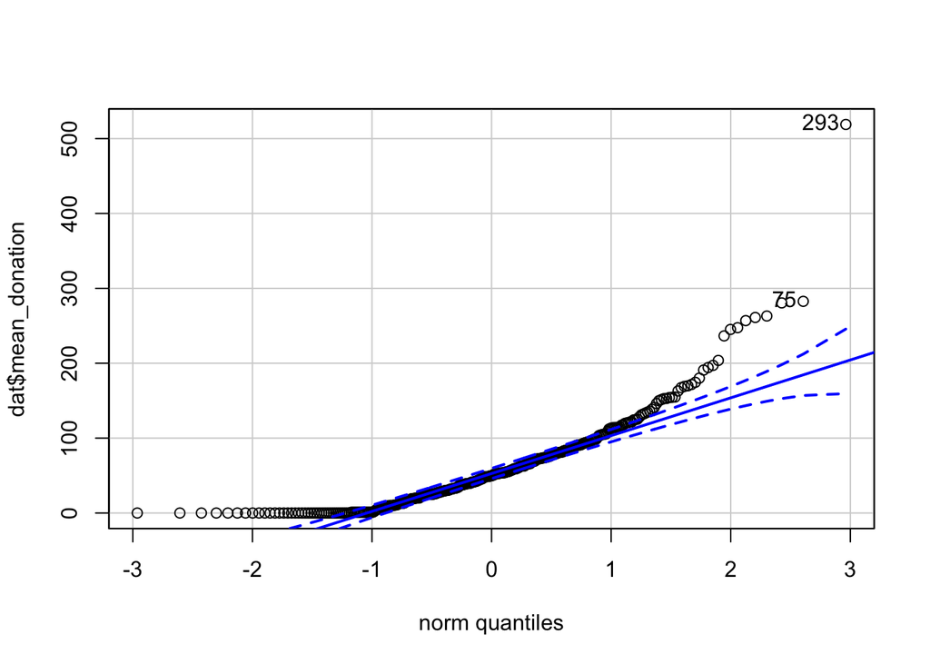

```
## [1] 293  75
```

```r
qqp(dat$mean_donation)
```

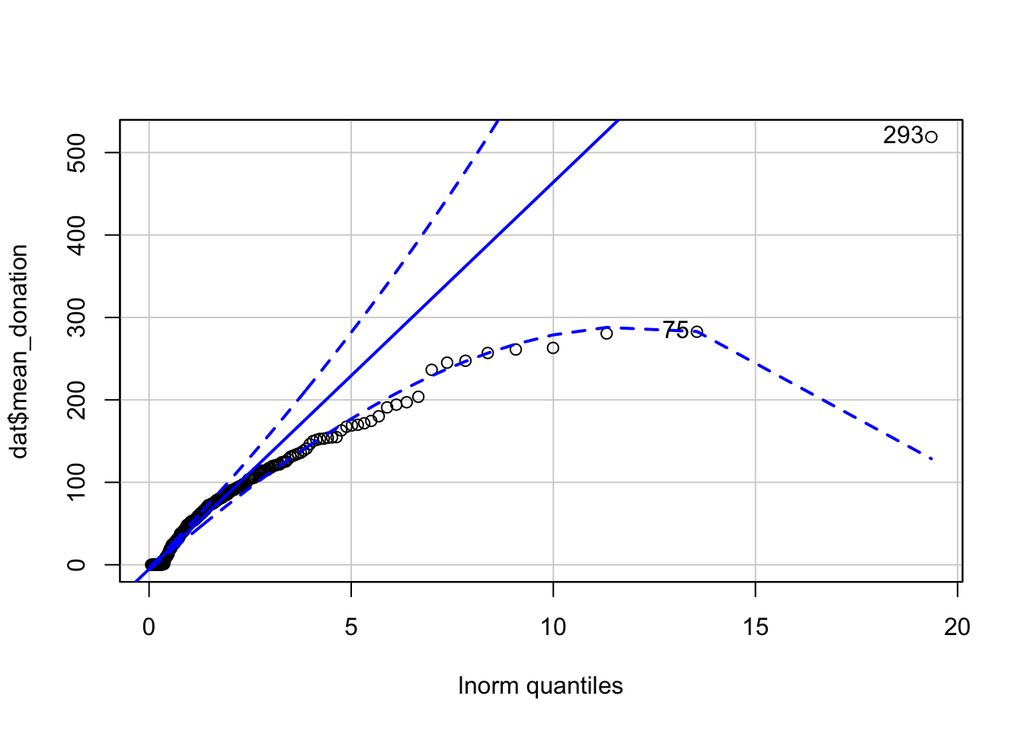

```
## [1] 293  75
```

```r
qqp(dat$mean_donation, "lnorm")
```